# Basic Text Mining in R

# Word cloud

Note: The “set.seed()”" function just makes the configuration of the layout of the clouds consistent each time you plot them. You can omit that part if you are not concerned with preserving a particular layout.

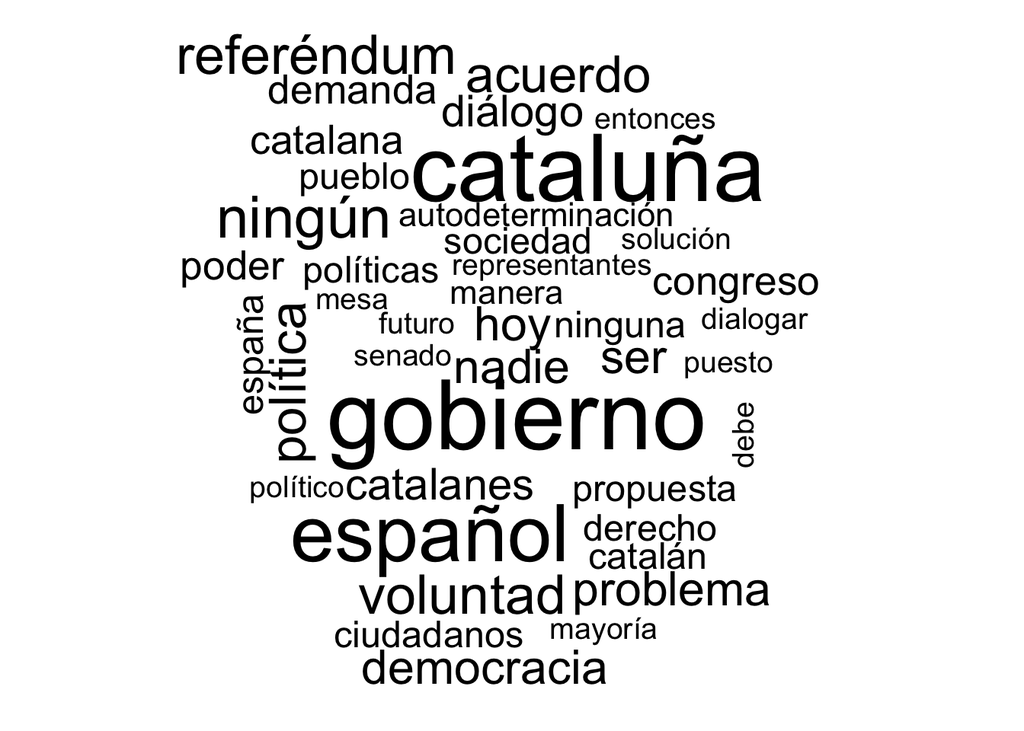

```r
set.seed(142)
wordcloud(names(freq), freq, min.freq=5)
```

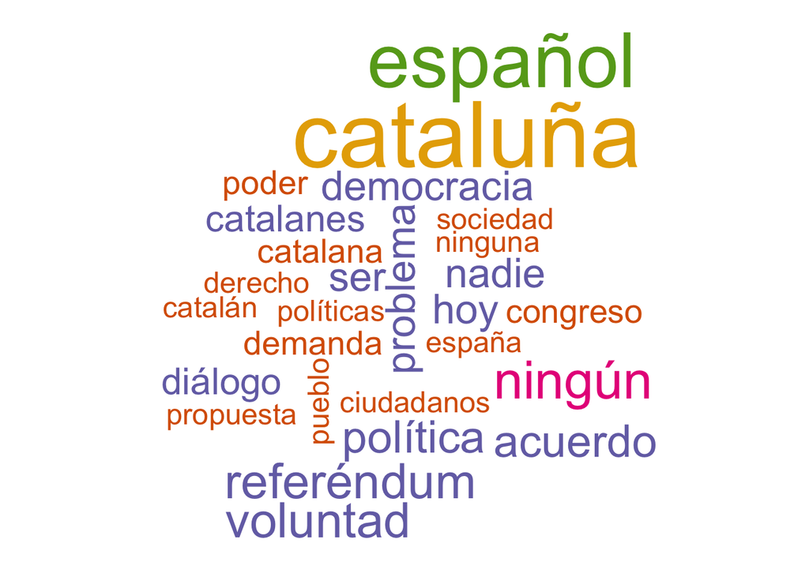

```r
wordcloud(names(freq), freq, min.freq=7, scale=c(5, .1), colors=brewer.pal(6, "Dark2"))
```

From the word cloud we observe very neatly the main message Puigdemont wanted to convey in his speech in Madrid. Madrid had left his government with no choice but to call the vote. Lies, lies and lies! If people knew what happens in Cataluna they would be shocked. In essence, democracy there has been kindnapped. Education and puclic tv to put some examples are labs that just generate hate and promote deliverately factual errors in support of their conclusions. Anecdotly, here is a link in Spanish to how education works in that part of Spain that no longer wants to obey their own laws [^1].

To learn more about text mining specifically, or data mining in general, I suggest you vist “Text Mining with R” [^2] and this article [^3] that explains very well the whole process.

[^1]: Link2 (http://www.elmundo.es/espana/2017/09/26/59c91dbf468aebe2658b4590.html)
[^2]: Link1 (http://tidytextmining.com/topicmodeling.html)
[^3]: Link2 (https://rpubs.com/pjmurphy/265713)